# Identification of Factors Associcated with Diabetes in the USA

Mercy Atuahene

February 19, 2025

## Abstract

This analysis explores missing value imputation techniques that can be employed as part of data preparation for machine learning methodologies. It is based on a sample data from the Diabetes Health Indictors dataset (BRFSS 2015). We briefly review the nature of missing values and the methods of imputation that are often used in machine learning both for categorical and numeric feature variable imputation. Then we develop models to impute missing values using multiple imputation and compare two imputation methods drawing insights and providing recommendations for further analysis.

## 1. Introduction

Missing data is common in all kinds of datasets and a persistent problem in statistical analyses. They have the potential to significantly impact the quality and reliability of analysis. See [Book Chapter on Missing Data](https://bookdown.org/mike/data_analysis/imputation-missing-data.html). For instance, in most statistical procedures, sample size may be reduced when records with missing data on certain variables involved in the analysis are removed based on the models of the procedures which can lead to unreliable parameter estimates. Imputation is generally used to handle missing data by replacing missing values with likely values based on the data. Several reasons are responsible for missing data including participants not responding to questions, equipment for data collection issues, poorly structured questionnaires, social desirability issues, etc. Understanding why and how missing data comes about in any analysis is critical to guiding researchers choose the best statistical methods in handling them.

Missing data is often classified into 3 main groups of mechanism of occurrence. They are:

- **Missing at Random (MAR)**: In this mechanism, the missing data is related to the observed data but not the unobserved or missing data. Thus, the probability of that a value is missing depends on other variables in the analysis dataset that has observed values of other variables but not related to the value of the missing data. It assumes that the observed data provides enough information to describe the missing. In this type of missing data, we can handle the missing data through imputation methods such as multiple imputation (MI), maximum likelihood estimation (MLE) as they can account for the data patterns to minimize the impact of the missing values because the data is not completely missing at random.
- **Missing Completely at Random (MCAR)**: This occurs when the missingness is unrelated to the observed or non-missing data and unobserved data. In this type of missing data, no bias will be introduced into the analysis by the missing data and the missing values may be ignored in the analysis or simple approach to replacing them with an imputed value will not introduce bias.
- **Missing Not at Random (MNAR)**: In this type of missing data, the missingness is related to the unobserved data. It is the most challenging type of missing data because of this. If this type of missing data is ignored, it can introduce bias in statistical model estimates and invalid results. In this type of missing data, the missingness often must be modeled posing challenges to data analysis. Traditional approached to handling missing data as in the case of MAR and MCAR do not apply in the case of MNAR.

As stated above, imputation is generally used to address missing data. Some of the ways used to handle missing data via imputation are:

**Single value imputation** like mean/mode/median imputation where the mode is often applicable to categorical data. This method though easy has the potential to distort relationships in the data and reduce variability. For categorical variables, the mode is one way used to replace missing values. Alternative to the mode is using k-nearest neighbors algorithm to impute missing values.

**Likelihood based imputation**: These rely on the likelihood function to estimate the missing values. Examples include Expectation Maximization (EM), Multiple imputation, Bayesian approaches, Full Information Maximum Likelihood (FIML), outcome regression, etc.

**Multiple Imputation**: This approach is based on regression models to predict the missing values through the process of creating multiple complete datasets and then combining the results from each in an effort to account for uncertainty associated with the missing values. These approaches are considered the preferred methods for handling missing data.

In choosing an effective approach to handling missing data, the following are recommended as the guiding principles – techniques that ensure that parameter estimates are unbiased particularly in MAR and MNAR missingness, methods that preserve the statistical power (detecting an effect if one exists- reducing the risk of Type II errors where a true effect is missed) and enables robust hypothesis testing (reliable methods even when certain assumptions are violated) and model estimation and those that accurately estimates standard errors for reliable p-values and confidence intervals. Methods like single imputation underestimate standard errors and lead to overconfident conclusions.

## 2. Replacement Imputation for Categorical Features

To preserve sample size in our analysis, we employed replacement methods of categorical feature variables to demonstrate how these methods are utilized. We used the mode to replace missing values for the following variables.

```r
# get data into R
ddat <- read.csv("https://matuahene.github.io/STA552/Week%202/diabetes_binary_health_indicators_BRFSS2015.csv", skip=0)


# Categorize income variable
ddat$Income_cat <- cut(ddat$Income,
                                    breaks = c(-Inf, 3, 5, 6, Inf),
                                    labels = c("Low", "Medium", "High", "Very High"))

#table(ddat$Income , ddat$Income_cat )

ddat2 <-ddat
#colSums(is.na(ddat2))


# assign meaningful labels to Age
ddat2$Age <- factor(ddat2$Age,
  levels = 1:13,
  labels = c("18-24", "25-29", "30-34", "35-39", "40-44",
             "45-49", "50-54", "55-59", "60-64", "65-69",
             "70-74", "75-79", "80+"))



# BMI categories
ddat2 <- ddat2 %>%
  mutate(BMI_Cat = cut(BMI,
                            breaks = c(0, 18.5, 24.9, 29.9, Inf),
                            labels = c("Underweight", "Normal", "Overweight", "Obese")))



# YES/NO labels
ddat2 <- ddat2 %>%
  mutate(
    HighChol = recode(HighChol, "0" = "No", "1" = "Yes"),
    HighBP = recode(HighBP, "0" = "No", "1" = "Yes"),
    Smoker = recode(Smoker, "0" = "No", "1" = "Yes"),
    Stroke = recode(Stroke, "0" = "No", "1" = "Yes"),
    HeartDiseaseorAttack = recode(HeartDiseaseorAttack, "0" = "No", "1" = "Yes"),
    PhysActivity = recode(PhysActivity, "0" = "No", "1" = "Yes"),
    Fruits = recode(Fruits, "0" = "No", "1" = "Yes"),
    Veggies = recode(Veggies, "0" = "No", "1" = "Yes")
  )


#Diabetes status, Education and Income, etc labels
ddat2 <- ddat2 %>%
  mutate(
    Education = recode(Education,
                       "1" = "No High School",
                       "2" = "Some High School",
                       "3" = "High School Graduate",
                       "4" = "Some College",
                       "5" = "College Graduate",
                       "6" = "College 4 years or more (College graduate)"),
    Income = recode(Income,
                    "1" = "<$10K",
                    "2" = "$10K-$15K",
                    "3" = "$15K-$25K",
                    "4" = "$25K-$35K",
                    "5" = "$35K-$50K",
                    "6" = "$50K-$75K",
                    "7" = ">$75K",
                    .default = "Unknown"),
   Sex = recode(Sex,
                  "1" = "Male",
                  "0" = "Female",
                .default = "Unknown"),
   CholCheck = recode(CholCheck,
                      "1" = "Yes",
                      "0" = "No" ),

   DiffWalk = recode(DiffWalk,
                      "1" = "Yes",
                      "0" = "No" ),

   AnyHealthcare = recode(AnyHealthcare,
                      "1" = "Yes",
                      "0" = "No" ),

   NoDocbcCost = recode(NoDocbcCost,
                      "1" = "Yes",
                      "0" = "No" ),
  HvyAlcoholConsump = recode(HvyAlcoholConsump,
                      "1" = "Yes",
                      "0" = "No" ),
    Diabetes_binary = recode(Diabetes_binary,
                            "0" = "No Diabetes",
                            "1" = "Has Diabetes"),

  GenHlth = recode(GenHlth,
                  "1" = "Excellent",
                   "2" = "Very Good",
                   "3" = "Good",
                   "4" = "Fair",
                   "5" = "Poor",
                   .default = "Unknown")
  )


nonemiss_dat<-ddat2

#table (ddat2$Income)
#unique(ddat2$Income)

# create some missing data points
# Define the percentage of missing values
missing_percentage <- 0.05

# Get total number of rows
total_rows <- nrow(ddat2)

# Apply missing values to all variables
ddat2 <- ddat2 %>%
  mutate(across(everything(), ~ {
    miss_id <- sample(1:total_rows, size = round(missing_percentage * total_rows), replace = FALSE)
    .[miss_id] <- NA  # Assign NA to selected rows
    .
  }))

# overall summary of variables
#dfSummary(ddat2)

#missing values data
misingdat <- ddat2
forMICE <- ddat2 # reserve data for MICE imputation

# Generate a summary table only for missing rows: +HighBP+CholCheck+HeartDiseaseorAttack+GenHlth+HvyAlcoholConsump+CholCheck+AnyHealthcare+Income+BMI_Cat+Education
summissing<-table1(~Sex+Smoker+Stroke,
       data=misingdat,
       caption="Table 1: Descriptive Statistics showing select categorical feature variables with missing data (count/percentages)",
       footnote="Data source:BRFSS Diabetes Dataset", topclass="Rtable1-zebra")
```

```r
#function to replace missing values with the mode of categorical variables
replace_na_with_mode <- function(x) {
  if (is.factor(x)) x <- as.character(x)  # Convert factor to character

  # Remove NA values for calculating the mode
  x_no_na <- x[!is.na(x)]

  # Find the mode using the non-missing values
  mode_value <- names(sort(table(x_no_na), decreasing = TRUE))[1]

  # Replace only NA values with the mode (without altering non-missing values)
  x[is.na(x)] <- mode_value

  # Convert back to factor if the original variable was a factor
  return (x)

}


ddat2_mod <- ddat2 %>%
  mutate(across(c("Sex", "Income", "BMI_Cat", "Education", "Smoker", "Stroke", "HighBP", "CholCheck",
                  "HeartDiseaseorAttack", "GenHlth", "HvyAlcoholConsump", "CholCheck", "AnyHealthcare"),
                replace_na_with_mode))
#dfSummary(ddat2_mod)

#table(misingdat$Sex, useNA = "ifany")  # `useNA = "ifany"` includes NA counts
#table(ddat2_mod$Sex)  # `useNA = "ifany"` includes NA counts


# Generate a summary table only for missing rows
summnonissing<-table1(~Sex+Smoker+Stroke,
       data=ddat2_mod,
       caption="Table 1: Descriptive Statistics of Select categorical feature variables with missing replaced by mode",
       footnote="Data source:BRFSS Diabetes Dataset", topclass="Rtable1-zebra")



# Use grid.arrange to print the tables side by side
#summissing
#summnonissing
# Remove everything explicitly, including hidden variables (like functions)
#rm(list = ls(all = TRUE))
```

```r
kable(summissing, caption = 'Table showing data summary including summary of missing data')
```

Table 1: Table showing data summary including summary of missing data

|  | Overall |
| --- | --- |
|  | (N=253680) |
| Sex |  |
| Female | 134865 (53.2%) |
| Male | 106131 (41.8%) |
| Missing | 12684 (5.0%) |
| Smoker |  |
| No | 134158 (52.9%) |
| Yes | 106838 (42.1%) |
| Missing | 12684 (5.0%) |
| Stroke |  |
| No | 231238 (91.2%) |
| Yes | 9758 (3.8%) |
| Missing | 12684 (5.0%) |

```r
kable(summnonissing, caption = 'Table showing missing data replaced with mode summary')
```

Table 2: Table showing missing data replaced with mode summary

|  | Overall |
| --- | --- |
|  | (N=253680) |
| Sex |  |
| Female | 147549 (58.2%) |
| Male | 106131 (41.8%) |
| Smoker |  |
| No | 146842 (57.9%) |
| Yes | 106838 (42.1%) |
| Stroke |  |
| No | 243922 (96.2%) |
| Yes | 9758 (3.8%) |

From **Tables 1 and 2**, Table 1 showa the summary of select feature variables that presents missing and non-missing data. In Table 2, however, the same summary rows with missing category are replaced by the value of the mode value of the corresponding variable and hence no missing rows. Example Sex had a mode value = Female and the number of missing in Table 1 is replaced by Female resulting in the summary greater than 58% from around 53% Females.

```r
  BMI_mean <- mean(misingdat$BMI, na.rm = TRUE)          # Calculate BMI mean
  MentHlth_mean <- mean(misingdat$MentHlth , na.rm = TRUE)  # Calculate MentHlth mean
  PhysHlth_mean <- mean(misingdat$PhysHlth, na.rm = TRUE)  # Calculate PhysHlth mean

  summary_data1 <- data.frame(BMI_mean,MentHlth_mean,PhysHlth_mean)

kable(summary_data1,
      caption = "Summary of Mean Values for BMI, Poor Mental Health in past 30 days, and Number of days of Poor Physical Health with no imputation",
      col.names = c("BMI_Mean", "MentHlth_mean", "PhysHlth_mean"),
      format = "markdown",
      digits = 2)
```

Table 3: Summary of Mean Values for BMI, Poor Mental Health in past 30 days, and Number of days of Poor Physical Health with no imputation

| BMI_Mean | MentHlth_mean | PhysHlth_mean |
| --- | --- | --- |
| 28.38 | 3.18 | 4.24 |

```r
# using the Hmisc package to impute data
ddat2_mod$BMI <- impute(ddat2_mod$BMI, fun = mean)
ddat2_mod$MentHlth <- impute(ddat2_mod$MentHlth, fun = median)
ddat2_mod$PhysHlth <- impute(ddat2_mod$PhysHlth, fun = median)

    BMI_mean <- mean(ddat2_mod$BMI, na.rm = TRUE)          # Calculate BMI mean
    MentHlth_mean <- mean(ddat2_mod$MentHlth , na.rm = TRUE)  # Calculate MentHlth mean
    PhysHlth_mean <- mean(ddat2_mod$PhysHlth, na.rm = TRUE)  # Calculate PhysHlth mean

summary_data <- data.frame(BMI_mean,MentHlth_mean,PhysHlth_mean)

kable(summary_data,
      caption = "Summary of Mean Values for BMI, Poor Mental Health in past 30 days, and Number of days of Poor Physical Health using Hmisc impute function",
      col.names = c("BMI_Mean", "MentHlth_mean", "PhysHlth_mean"),
      format = "markdown",
      digits = 2)
```

Table 4: Summary of Mean Values for BMI, Poor Mental Health in past 30 days, and Number of days of Poor Physical Health using Hmisc impute function

| BMI_Mean | MentHlth_mean | PhysHlth_mean |
| --- | --- | --- |
| 28.38 | 3.02 | 4.03 |

```r
# using the VIM package to impute data using the knn algorithm
# Select the columns to impute (e.g., 'Age' and 'Height')
data_to_impute <- misingdat[, c("BMI", "MentHlth", "PhysHlth", "Veggies")]

# Perform KNN imputation on the selected columns
#install.packages("yaImpute")
#library(yaImpute)
# Impute missing data using KNN from the FNN package
#temp_imputed_data <- knnImpute(data_to_impute, k = 2)


#chooseCRANmirror()
#install.packages("DMwR")
#library(DMwR)
library(VIM)
temp_imputed_data <- kNN(data_to_impute[1:15000, ], k = 2) # using a sample due to memeory issues for demonstration
temp_imputed_data <- temp_imputed_data[, c("BMI", "MentHlth", "PhysHlth", "Veggies")]

missing_summary <- data.frame(
  Variable = colnames(data_to_impute),
  Missing = colSums(is.na(data_to_impute)),
  Non_Missing = colSums(!is.na(data_to_impute))
)

kable(missing_summary,
      caption = "Summary of Imputation of select feature vriables without using kNN algorithm on a sample",
      col.names = c( ),
      format = "markdown",
      digits = 2)
```

Table 5: Summary of Imputation of select feature vriables without using kNN algorithm on a sample

| BMI | BMI | 12684 | 240996 |
| --- | --- | --- | --- |
| MentHlth | MentHlth | 12684 | 240996 |
| PhysHlth | PhysHlth | 12684 | 240996 |
| Veggies | Veggies | 12684 | 240996 |

```r
missing_summary1 <- data.frame(
  Variable = colnames(temp_imputed_data),
  Missing = colSums(is.na(temp_imputed_data)),
  Non_Missing = colSums(!is.na(temp_imputed_data))
)

kable(missing_summary1,
      caption = "Summary of Imputation of select feature vriables using kNN algorithm on a sample",
      col.names = c( ),
      format = "markdown",
      digits = 2)
```

Table 6: Summary of Imputation of select feature vriables using kNN algorithm on a sample

| BMI | BMI | 0 | 15000 |
| --- | --- | --- | --- |
| MentHlth | MentHlth | 0 | 15000 |
| PhysHlth | PhysHlth | 0 | 15000 |
| Veggies | Veggies | 0 | 15000 |

In **Table 5**, we use kNN algorithm to replace a sample of the dataset to demonstrate the method as a result of computer memory issues while using the VIM package on the diabetes whole dataset. In this table, there number of missing and non-missing values are presented on the tables but in **Table 6**, the number of missing = zero for all selected feature variables using the kNN algorithm. This method works for both categorical and numeric variables as observed in the Veggies and BMI variables respectively and the results presented covers both type of variables. The approach is further used to impute missing values in the regression imputation sections below.

## 3. Regression-based Imputation for Mnumerical/Categorical Features

```r
# first predicting missing target variable using using variables related to the target variable
# Step 1: Fit logistic regression model (only uses complete cases)
misingdat<-ddat2
misingdat$Diabetes_binary <- as.factor(misingdat$Diabetes_binary) #ensures the target variable is a factor

misingdat$Diabetes_binaryn<- ifelse(misingdat$Diabetes_binary == "Has Diabetes", 1,
                                            ifelse(misingdat$Diabetes_binary == "No Diabetes", 0, NA))

#table(misingdat$Diabetes_binaryn, useNA = "ifany")

# Convert character variables to factors
misingdat$Smoker <- factor(misingdat$Smoker, levels = c("No", "Yes"))
misingdat$Sex <- factor(misingdat$Sex, levels = c("Male", "Female"))
misingdat$HighBP <- factor(misingdat$HighBP, levels = c("No", "Yes"))
misingdat$HeartDiseaseorAttack <- factor(misingdat$HeartDiseaseorAttack, levels = c("No", "Yes"))
misingdat$HvyAlcoholConsump <- factor(misingdat$HvyAlcoholConsump, levels = c("No", "Yes"))
misingdat$HighChol <- factor(misingdat$HighChol, levels = c("No", "Yes"))
misingdat$Stroke <- factor(misingdat$Stroke, levels = c("No", "Yes"))
misingdat$Education <- factor(misingdat$Education)
misingdat$GenHlth <- factor(misingdat$GenHlth)
misingdat$Income_cat <- factor(misingdat$Income_cat)

imp.model = glm(Diabetes_binaryn ~ Income_cat + Smoker + BMI + Age + Sex + Education + GenHlth + MentHlth + PhysHlth + HighBP + HeartDiseaseorAttack +  HvyAlcoholConsump + HighChol + Stroke,
                data = misingdat, family = binomial)

#formula(imp.model)
#tidy(imp.model)

# Step 2: Identify rows where y is missing
newdata = misingdat[is.na(misingdat$Diabetes_binaryn),]
#head(newdata)

# Step 3: Predict missing y values (probability estimates)
pred.Diabetes_binaryn = predict(imp.model, newdata, type = "response")

#print (pred.Diabetes_binary)
#summary(pred.Diabetes_binaryn, useNA = "ifany") # why does the number of missing still remain


# Step 4: Convert probabilities to binary values (threshold = 0.5)
misingdat$Diabetes_binaryn[is.na(misingdat$Diabetes_binaryn)] = ifelse(pred.Diabetes_binaryn > 0.5, 1, ifelse(pred.Diabetes_binaryn < 0.5, 0, NA))

#check missing after prediction to impute target variable
#table (misingdat$Diabetes_binaryn, useNA = "ifany"). # why do we still have some missing though reduced


# Step 5: Display the updated dataset
#kable(misingdat)
```

## 4. Multiple Imputation

Missing data poses challenges that lead to biased estimates and reduced statistical power. One approach used to to address this is multiple imputation methods, such as the **Multivariate Imputation by Chained Equations (MICE)** procedure. This apparoach generates plausible values for missing observations in order to improve the robustness of regression models.

```r
#make this example reproducible
set.seed(23)

#select random sample of 1,000,000 rows from data frame
rand_forMICE_dat0 <- forMICE[sample(nrow(forMICE), size=20000, replace = FALSE), ]

rand_forMICE_dat0$Diabetes_binaryn <- ifelse(rand_forMICE_dat0$Diabetes_binary == "Has Diabetes", 1,
                                            ifelse(rand_forMICE_dat0$Diabetes_binary == "No Diabetes", 0, NA))
#table(forMICE$Diabetes_binary )
#table(rand_forMICE_dat0$Diabetes_binaryn,useNA="always")
#table(rand_forMICE_dat0$HeartDiseaseorAttack ,useNA="always")
#dim(rand_forMICE_dat)  # Check the number of rows and columns
#colnames(rand_forMICE_dat)  # Ensure only selected columns exist

#forMICE  data set with missing values
## individual variables to be imputed
rand_forMICE_dat <- rand_forMICE_dat0 [, c("Diabetes_binaryn", "Income_cat",  "Smoker",  "BMI",  "Age" ,"Sex", "Education", "GenHlth",
                                           "MentHlth",  "PhysHlth", "HighBP" ,"HeartDiseaseorAttack" ,  "HvyAlcoholConsump" , "HighChol" ,
                                           "Stroke")]


# Convert character variables to factors
rand_forMICE_dat$Smoker <- factor(rand_forMICE_dat$Smoker, levels = c("No", "Yes"))
rand_forMICE_dat$Sex <- factor(rand_forMICE_dat$Sex, levels = c("Male", "Female"))
rand_forMICE_dat$HighBP <- factor(rand_forMICE_dat$HighBP, levels = c("No", "Yes"))
rand_forMICE_dat$HeartDiseaseorAttack <- factor(rand_forMICE_dat$HeartDiseaseorAttack, levels = c("No", "Yes"))
rand_forMICE_dat$HvyAlcoholConsump <- factor(rand_forMICE_dat$HvyAlcoholConsump, levels = c("No", "Yes"))
rand_forMICE_dat$HighChol <- factor(rand_forMICE_dat$HighChol, levels = c("No", "Yes"))
rand_forMICE_dat$Stroke <- factor(rand_forMICE_dat$Stroke, levels = c("No", "Yes"))
rand_forMICE_dat$Education <- factor(rand_forMICE_dat$Education)
rand_forMICE_dat$GenHlth <- factor(rand_forMICE_dat$GenHlth)
rand_forMICE_dat$Income_cat <- factor(rand_forMICE_dat$Income_cat)

#implement MICE
imp5 <- mice(rand_forMICE_dat, method = c("logreg", "polyreg", "logreg", "pmm", "polyreg", "logreg", "polyreg", "polyreg", "pmm",
                                    "pmm", "logreg",  "logreg", "logreg", "logreg", "logreg"),
                 maxit = 10,  # iterating 10 cycles to complete each imputed data set
                 m = 5,       # generate 5 imputed data set
                 seed = 134,
                 print=F)     # suppress printouts

#summary(imp5)
#plot(imp5)  # Visualize imputed vs. observed data
```

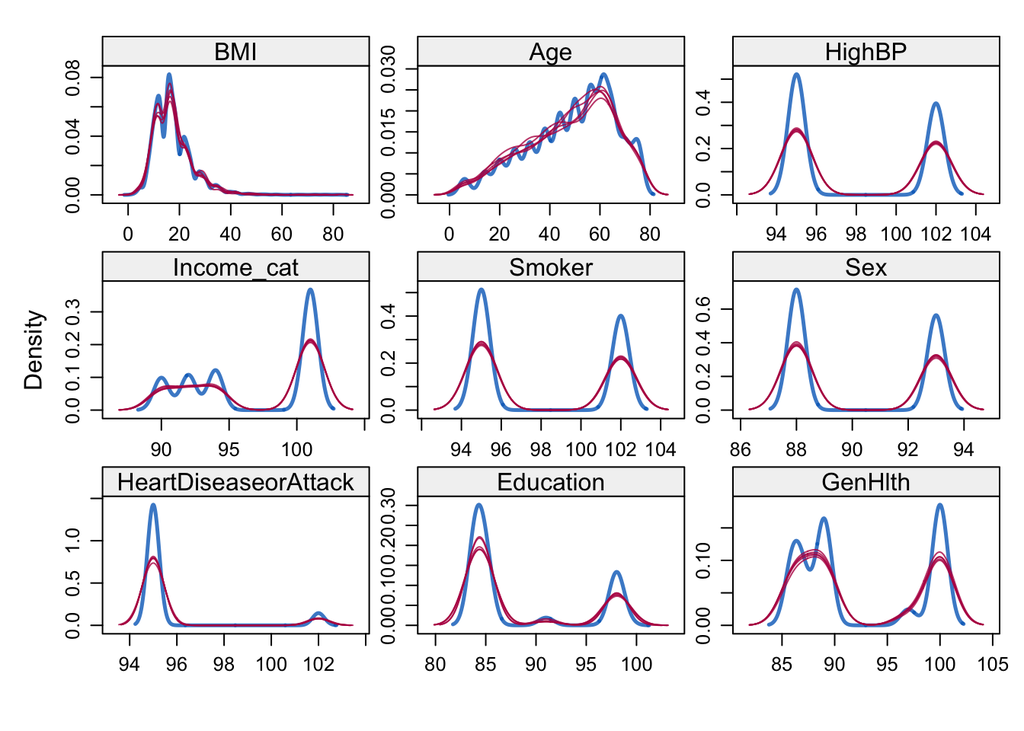

Figure 1: Density Plots of Select Feature Variable: Comparison of observed data vs predicte data via MICE

```r
# view desity plot of some select variables
densityplot(imp5, ~BMI + Age + HighBP + Income_cat + Smoker + Sex + HeartDiseaseorAttack + Education + GenHlth)
```

```r
#ls(all.names = TRUE)

#Model on MICE-Imputed Data
model5 <- with(imp5,  glm(Diabetes_binaryn ~ Income_cat + Smoker + BMI + Age + Sex + Education + GenHlth + MentHlth + PhysHlth + HighBP +
                          HeartDiseaseorAttack +  HvyAlcoholConsump + HighChol + Stroke,
                          family = binomial))  # The statistical model to assess
                                             # the relationship between Target and independent variables
summary.stats = summary(model5)               # display the regression results of
                                             # individual imputed data set.
#summary.stats
```

```r
## Pools the results across multiple imputations
kable(summary(pool(model5)) , caption = 'Table showing Pooled results across multiple imputations using MICE')
```

Table 7: Table showing Pooled results across multiple imputations using MICE

| term | estimate | std.error | statistic | df | p.value |
| --- | --- | --- | --- | --- | --- |
| (Intercept) | -7.6740271 | 0.6174220 | -12.4291449 | 79.30856 | 0.0000000 |
| Income_catMedium | -0.2059553 | 0.0811531 | -2.5378599 | 48.93153 | 0.0143885 |
| Income_catHigh | -0.3106902 | 0.0909717 | -3.4152414 | 65.04748 | 0.0011022 |
| Income_catVery High | -0.3753073 | 0.0825130 | -4.5484631 | 44.82975 | 0.0000409 |
| SmokerYes | -0.0375874 | 0.0488226 | -0.7698778 | 654.98425 | 0.4416499 |
| BMI | 0.0633087 | 0.0036382 | 17.4012511 | 106.78889 | 0.0000000 |
| Age25-29 | 0.7139922 | 0.6157639 | 1.1595226 | 1854.13162 | 0.2463925 |
| Age30-34 | 0.3233466 | 0.6176460 | 0.5235144 | 322.16475 | 0.6009762 |
| Age35-39 | 1.3029051 | 0.5749680 | 2.2660478 | 279.19033 | 0.0242141 |
| Age40-44 | 1.6480285 | 0.5706806 | 2.8878301 | 229.96497 | 0.0042491 |
| Age45-49 | 1.9325821 | 0.5722325 | 3.3772673 | 166.87968 | 0.0009110 |
| Age50-54 | 2.3117298 | 0.5603840 | 4.1252603 | 243.19938 | 0.0000509 |
| Age55-59 | 2.2462803 | 0.5625127 | 3.9932973 | 214.38059 | 0.0000895 |
| Age60-64 | 2.3711970 | 0.5653320 | 4.1943439 | 185.17959 | 0.0000424 |
| Age65-69 | 2.6644272 | 0.5674473 | 4.6954616 | 167.71697 | 0.0000055 |
| Age70-74 | 2.6686286 | 0.5697508 | 4.6838523 | 161.37451 | 0.0000059 |
| Age75-79 | 2.5675543 | 0.5645803 | 4.5477222 | 217.95675 | 0.0000090 |
| Age80+ | 2.2575728 | 0.5683286 | 3.9723021 | 190.71307 | 0.0001008 |
| SexFemale | -0.2227715 | 0.0557557 | -3.9954944 | 51.57414 | 0.0002058 |
| EducationCollege Graduate | 0.1484155 | 0.0637503 | 2.3280749 | 340.36233 | 0.0204936 |
| EducationHigh School Graduate | 0.2736601 | 0.1202951 | 2.2749066 | 105.52048 | 0.0249334 |
| EducationNo High School | -0.5078368 | 0.7614394 | -0.6669431 | 54.94594 | 0.5075997 |
| EducationSome College | 0.1338466 | 0.0683110 | 1.9593700 | 132.24248 | 0.0521730 |
| EducationSome High School | 0.2428604 | 0.1644324 | 1.4769615 | 91.32643 | 0.1431261 |
| GenHlthFair | 2.0070741 | 0.1358764 | 14.7713260 | 564.19832 | 0.0000000 |
| GenHlthGood | 1.5760184 | 0.1254147 | 12.5664579 | 1044.86508 | 0.0000000 |
| GenHlthPoor | 2.1292508 | 0.1583464 | 13.4467908 | 1138.42431 | 0.0000000 |
| GenHlthVery Good | 0.8379492 | 0.1270558 | 6.5951293 | 2092.18670 | 0.0000000 |
| MentHlth | -0.0004935 | 0.0032081 | -0.1538258 | 151.40531 | 0.8779519 |
| PhysHlth | -0.0006252 | 0.0028466 | -0.2196170 | 2688.55037 | 0.8261861 |
| HighBPYes | 0.7327335 | 0.0544667 | 13.4528794 | 520.17641 | 0.0000000 |
| HeartDiseaseorAttackYes | 0.2134752 | 0.0661105 | 3.2290670 | 1051.07906 | 0.0012804 |
| HvyAlcoholConsumpYes | -1.0567859 | 0.1555405 | -6.7942830 | 1522.75703 | 0.0000000 |
| HighCholYes | 0.5191763 | 0.0522545 | 9.9355350 | 158.24204 | 0.0000000 |
| StrokeYes | 0.2309537 | 0.0935974 | 2.4675224 | 362.99625 | 0.0140658 |

In **Tables 7** , pooled summary from all 5 imputed datasets are presented from the MICE procedure is presented. Next we show the results of the same model using the original dataset.

```r
#Model on Original Data using the subset used for MICE


library(VIM)
set.seed(23)
ddat2_mod2 <- ddat2_mod[sample(nrow(ddat2_mod), size=20000, replace = FALSE), ]
ddat2_mod3 <- ddat2_mod2[, c("Diabetes_binary", "Income_cat",  "Smoker",  "BMI",  "Age" ,"Sex", "Education", "GenHlth",
                                           "MentHlth",  "PhysHlth", "HighBP" ,"HeartDiseaseorAttack" ,  "HvyAlcoholConsump" , "HighChol" ,
                                           "Stroke")]
ddat2_mod3$Diabetes_binaryn<- ifelse(ddat2_mod3$Diabetes_binary == "Has Diabetes", 1,
                                            ifelse(ddat2_mod3$Diabetes_binary == "No Diabetes", 0, NA))


ddat2_mod3 <- kNN(ddat2_mod3, k = 3) # using a sample due to memeory issues for demonstration


# Convert character variables to factors
ddat2_mod3$Smoker <- factor(ddat2_mod3$Smoker, levels = c("No", "Yes"))
ddat2_mod3$Sex <- factor(ddat2_mod3$Sex, levels = c("Male", "Female"))
ddat2_mod3$HighBP <- factor(ddat2_mod3$HighBP, levels = c("No", "Yes"))
ddat2_mod3$HeartDiseaseorAttack <- factor(ddat2_mod3$HeartDiseaseorAttack, levels = c("No", "Yes"))
ddat2_mod3$HvyAlcoholConsump <- factor(ddat2_mod3$HvyAlcoholConsump, levels = c("No", "Yes"))
ddat2_mod3$HighChol <- factor(ddat2_mod3$HighChol, levels = c("No", "Yes"))
ddat2_mod3$Stroke <- factor(ddat2_mod3$Stroke, levels = c("No", "Yes"))
ddat2_mod3$Education <- factor(ddat2_mod3$Education)
ddat2_mod3$GenHlth <- factor(ddat2_mod3$GenHlth)
ddat2_mod3$Income_cat <- factor(ddat2_mod3$Income_cat)




modelorig <- glm(Diabetes_binaryn ~ Income_cat + Smoker + BMI + Age + Sex + Education + GenHlth + MentHlth + PhysHlth + HighBP +
                          HeartDiseaseorAttack +  HvyAlcoholConsump + HighChol + Stroke,
                          data=ddat2_mod3, family = binomial)
# Extract coefficient summary as a data frame
model_summary <- as.data.frame(summary(modelorig)$coefficients)

# Print the table using kable
kable(model_summary, caption = "Regression Model Summary of Original Data")
```

Table 8: Regression Model Summary of Original Data

|  | Estimate | Std. Error | z value | Pr(>\|z\|) |
| --- | --- | --- | --- | --- |
| (Intercept) | -7.1695618 | 0.4819315 | -14.8767233 | 0.0000000 |
| Income_catMedium | -0.2321979 | 0.0648952 | -3.5780464 | 0.0003462 |
| Income_catHigh | -0.3724925 | 0.0740836 | -5.0280050 | 0.0000005 |
| Income_catVery High | -0.4455963 | 0.0638204 | -6.9820349 | 0.0000000 |
| SmokerYes | -0.0643409 | 0.0434543 | -1.4806580 | 0.1386977 |
| BMI | 0.0588142 | 0.0031158 | 18.8760415 | 0.0000000 |
| Age25-29 | 1.1711112 | 0.5103394 | 2.2947693 | 0.0217464 |
| Age30-34 | 1.1056543 | 0.4911789 | 2.2510216 | 0.0243842 |
| Age35-39 | 1.4924264 | 0.4758043 | 3.1366391 | 0.0017090 |
| Age40-44 | 1.7660970 | 0.4703126 | 3.7551557 | 0.0001732 |
| Age45-49 | 2.0264716 | 0.4655025 | 4.3532992 | 0.0000134 |
| Age50-54 | 2.3682942 | 0.4629727 | 5.1154084 | 0.0000003 |
| Age55-59 | 2.3624711 | 0.4623390 | 5.1098244 | 0.0000003 |
| Age60-64 | 2.4645662 | 0.4618286 | 5.3365385 | 0.0000001 |
| Age65-69 | 2.7059794 | 0.4615611 | 5.8626674 | 0.0000000 |
| Age70-74 | 2.6519960 | 0.4627625 | 5.7307922 | 0.0000000 |
| Age75-79 | 2.6136948 | 0.4647350 | 5.6240546 | 0.0000000 |
| Age80+ | 2.2282900 | 0.4654613 | 4.7872719 | 0.0000017 |
| SexFemale | -0.2052658 | 0.0437649 | -4.6901904 | 0.0000027 |
| EducationCollege Graduate | 0.0850380 | 0.0547028 | 1.5545460 | 0.1200542 |
| EducationHigh School Graduate | 0.3033531 | 0.1022793 | 2.9659298 | 0.0030177 |
| EducationNo High School | 0.0120153 | 0.5926586 | 0.0202735 | 0.9838252 |
| EducationSome College | 0.1145310 | 0.0562609 | 2.0357101 | 0.0417795 |
| EducationSome High School | 0.2463714 | 0.1411190 | 1.7458414 | 0.0808385 |
| GenHlthFair | 1.8630572 | 0.1175024 | 15.8554752 | 0.0000000 |
| GenHlthGood | 1.5492579 | 0.1085403 | 14.2735729 | 0.0000000 |
| GenHlthPoor | 1.9149465 | 0.1410972 | 13.5718269 | 0.0000000 |
| GenHlthVery Good | 0.9695306 | 0.1090648 | 8.8894900 | 0.0000000 |
| MentHlth | -0.0009588 | 0.0028180 | -0.3402524 | 0.7336665 |
| PhysHlth | 0.0029199 | 0.0025976 | 1.1240909 | 0.2609744 |
| HighBPYes | 0.6055714 | 0.0457637 | 13.2325767 | 0.0000000 |
| HeartDiseaseorAttackYes | 0.2573825 | 0.0623572 | 4.1275484 | 0.0000367 |
| HvyAlcoholConsumpYes | -0.8533239 | 0.1304714 | -6.5403143 | 0.0000000 |
| HighCholYes | 0.5191704 | 0.0441836 | 11.7503078 | 0.0000000 |
| StrokeYes | 0.2087371 | 0.0876887 | 2.3804338 | 0.0172923 |

The summary from the same model in the original data using the kNN approach appraoch is presented in **Table 8** above. Some differences in the model estimates across the 2 model summaries are observed on these tables.

Next, we **compare model performance from the MICE procedure with the original dataset imputation method** which uses the kNN procedure from above.

```r
library(MASS)

# AIC Comparison of models

# Extract fit statistics for each imputed model
mice_fits <- lapply(1:5, function(i) glm(Diabetes_binaryn ~ Income_cat + Smoker + BMI + Age + Sex + Education + GenHlth +
                                            MentHlth + PhysHlth + HighBP + HeartDiseaseorAttack +
                                            HvyAlcoholConsump + HighChol + Stroke,
                                            data = complete(imp5, i), family = binomial))

# Compute AIC for each model and average them
aic_values <- sapply(mice_fits, AIC)
bic_values <- sapply(mice_fits, BIC)

mean_aic <- mean(aic_values)
mean_bic <- mean(bic_values)

cat("Original Model AIC:", AIC(modelorig), "\n")
```

```
Original Model AIC: 14742.13
```

```r
cat("MICE Model Mean AIC:", mean_aic, "\n")
```

```
MICE Model Mean AIC: 12897.54
```

```r
cat("Original Model BIC:", BIC(modelorig), "\n")
```

```
Original Model BIC: 15018.75
```

```r
cat("MICE Model Mean BIC:", mean_bic, "\n")
```

```
MICE Model Mean BIC: 13174.16
```

In the **AIC** (Akaike Information Criterion) and **BIC** (Bayesian Information Criterion) values reported below, lower AIC implies better model fit and we can infer that the **Original Model AIC** is greater than the **MICE Model Mean AIC**. And the BIC from the **Original Model BIC** is also greater than that of **MICE Model Mean BIC** implying MICE imputation model perfoming better than the original dataset model without the multiple imputation approach.

```r
library(pROC)

# Predictions for original model
pred_original <- predict(modelorig, type = "response")

# Compute ROC and AUC for original data
roc_original <- roc(ddat2_mod3$Diabetes_binaryn, pred_original)

# Compute ROC and AUC for MICE-imputed models
mice_roc_aucs <- sapply(1:5, function(i) {
  mice_pred <- predict(mice_fits[[i]], type = "response")
  auc(roc(complete(imp5, i)$Diabetes_binaryn, mice_pred))
})

# Get the average AUC across imputed datasets
mean_auc_mice <- mean(mice_roc_aucs)

cat("Original Model AUC:", auc(roc_original), "\n")
```

```
Original Model AUC: 0.801851
```

```r
cat("MICE Model Mean AUC:", mean_auc_mice, "\n")
```

```
MICE Model Mean AUC: 0.8270949
```

Finally, we compare the models’ ability to classify the groups of our target feature variable. With **AUC < 0.82 from the original model** and **a mean AUC >= 0.82 from the MICE model**, both models do good at discriminating the groups well. However the values suggests that handling missing data with MICE imputation improved model performance overall.

**Implications**

- Impact or missing data on model performance: The predictive power of a model can be weakened if missing data is not handled cautiously. Proper imputation methos like the MICE approach should be considered when considering imputation.
- In clinical setting, the ability to tell which patients actually have disease is important. In this case, knowing who really has diabetes will help doctors access appropriate follow up care. This means AUC can be utilized to improved risk predinction and improved outcomes for patients. This will ultimately lead to physicians ability to better stratify patients.